# PsA GWAS

Boxi Lin

2020-01-15

# 1 Phenotype

## 1.1 PsA status

```
##
##              Missing            No growth            Grew once
##                    5                  394                  176
##      Sporadic growth Chronically infected    Pos.w.NA severity
##                  222                 1615                    0
```

The majority of patients are “Chronically infected”. For GWAS on `pa_age`, we will discard patients with “No growth”, “Missing” and “Positive with NA severity” PsA status. Similarly for GWAS on `pac_age`, we will only use “Chronically infected” patients.

## 1.2 Chronological distribution of patients’ date of birth and diagnose

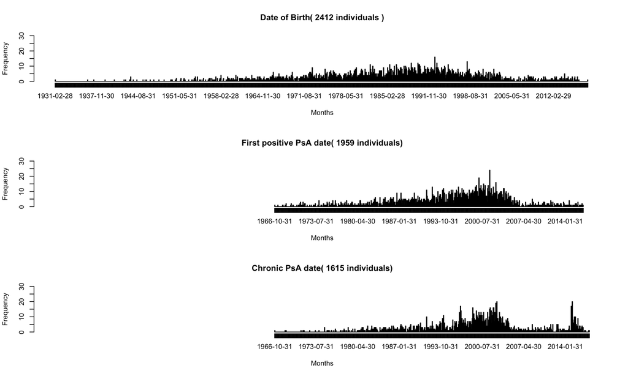

## 1.3 Response variables check

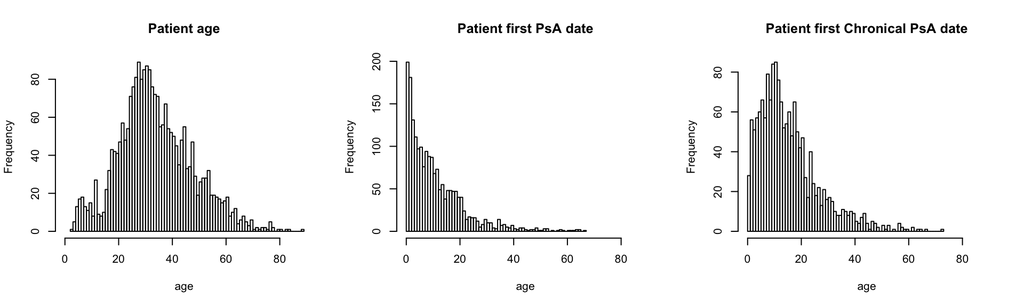

Both `pa_age` and `pac_age` are zero truncated, and scew to right. Although we use Gaussian regression for benchmark model, Possion family or log-transform of response may be considered.

## 1.4 CFTR score

```r
table(phenotype$cftr_score, useNA = "ifany")
```

```
##
##    0    1    2    3    4    5 <NA>
##   54  357  184 1266  435   61   55
```

## 1.5 Pairwise plot

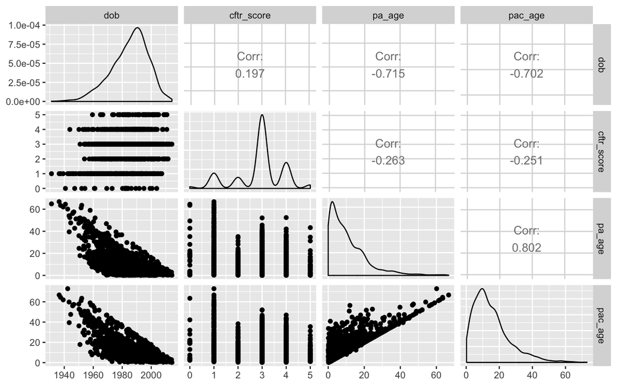

# 2 GWAS - dosage data

$$T: Pa~age|Pa~status=1;$$

## 2.1 Baseline model

$$E(T) = \alpha + \beta_jSNP_j$$

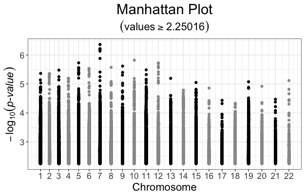

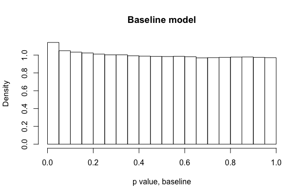

[figure not shown]

## 2.2 Log-transformed outcome

$$E(log(T)) = \alpha + \beta_jSNP_j$$

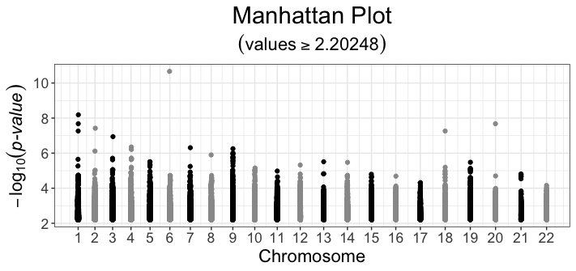

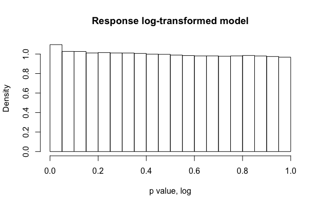

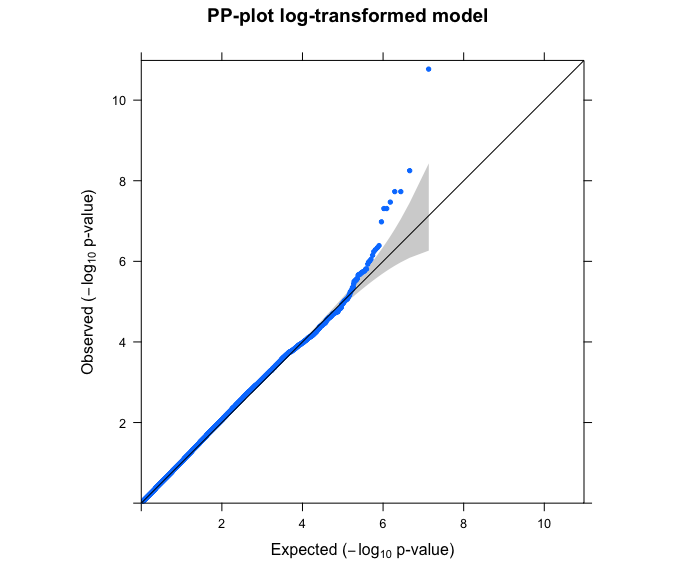

Some non-linear re-expression of the dependent variable is indicated when any of the following apply:

- The residuals have a skewed distribution. The purpose of a transformation is to obtain residuals that are approximately symmetrically distributed (about zero, of course).
- The spread of the residuals changes systematically with the values of the dependent variable (“heteroscedasticity”). The purpose of the transformation is to remove that systematic change in spread, achieving approximate “homoscedasticity.”
- To linearize a relationship.
- When scientific theory indicates. For example, chemistry often suggests expressing concentrations as logarithms (giving activities or even the well-known pH).
- When a more nebulous statistical theory suggests the residuals reflect “random errors” that do not accumulate additively.
- To simplify a model. For example, sometimes a logarithm can simplify the number and complexity of “interaction” terms.

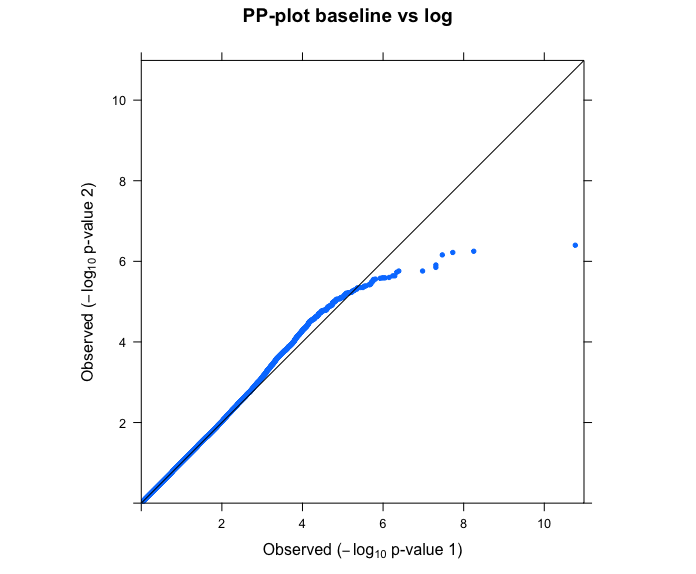

## 2.3 Log-link outcome

$$log(E(T)) = \alpha + \beta_jSNP_j$$

## 2.4 PCA; other covariates